# IODS course project: final assignment

Neli Noykova email: nnoykova’at’yahoo.com

08.03.2017

# Long healthy life and good education as measures for human development of given country: linear regression modeling approach.

## Abstract

We have investigated two multivariate models for **human** data, concerning different measures about assessing development of a country. The models are created under the assumption that economic growth is not measured only by the gross national income. In the first model we have investigated the long healthy life as output variable depending on education, income and mother mortality. The model analysis shows that the choice of dependent variables is correct and the model is a good approximation to the observed data. In the second model we investigate the possibility to obtain good education as output model variable, depending on life expectancy, gender inequality index and income. Surpisingly in this case the model show that income is not so significant variable and the output results do not become worst if we exclude it from the depending variables. We also have analysed the pairwise correlation plots and observe how the results are separated between proportion of female and male who have obtained secondary education.

## 6.1 Introduction

In our commercial world when unfortunately earning money becomes not just the main goal, but also meaning of more and more people’s life’s, it is natural to assume the economical growth as only measure of the development of a country. In order to avoid such misunderstanding, the Human Development Index (HDI) was created under the United Nations Development Programme. In this summary measure three main components are measured and involved: long and healthy life, access to knowledge, and only as a third componet - the gross national income as a measure for decent standard of living. The income is involved as a logarithmic function since too high income does not affect much the human development capabilities.

The main goal of this work is to investigate using linear regression models how the long and healthy life depends on education and gross income related variables. In order to justify the results some variables related to gender inequality are added. The gender inequality can lead to potential loss of human development due to inequality between the achievments of male and female. we also investigate how the education as output variable in linear regression depends on the other two groups of variables.

## 6.2.The data

The full **human** data from the United Nations Development Programme are originally published [here](http://hdr.undp.org/en/content/human-development-index-hdi), and the detailed description about all calculated indexes is provided [here](http://hdr.undp.org/sites/default/files/hdr2015_technical_notes.pdf). Part of these data sests have been used in [Exercise 5](https://noykova.github.io/IODS-project/#dimensionality-reduction-technique).

In this work we use only variables, needed for calculation of the human development index (HDI), and gender inequality index (GII).

The wrangling includes the following changes:

1. As in the previous Exercise 5, here we also join both groups of data on “country” column using inner join.
2. One new column **Edu2.FM** is added to “Gender inequality” data. Since we are intersted in influense of genwer inequality, we investigate only the ratio between female and male with secondary education, not both variables separately.
3. Next “Gender inequality” and “Human development” data are joined using the variable Country as the identifier.
4. The variable Gross National Income (GNI) is transformed to numeric. Only the columns **c(“Country”, “Edu2.FM”, “Edu.Mean”, “Edu.Exp”, “Life.Exp”, “GNI_num”, “Mat.Mor”, “Ado.Birth”, “GII”)** are selected for further work.
5. The rows with missing values are removed. The last 7 observations relate to regions instead of countries. Therefore they are removed.
6. The country names are added as rownames and the corresponding ciolumn is removed from data frame.
7. We check the data and observe different dimensions. In order to be able to compare obtained result we provide suitable nomalization. We first follow the normalization formulas, suggested in the [original article](http://hdr.undp.org/sites/default/files/hdr2015_technical_notes.pdf). After comparing results we chose to normalize data using standard formula because we do not want to truncate values from the original data.

7.1 The health index **Life.I** = (Life.Exp -min(Life.Exp))/(max(Life.Exp) -min(Life.Exp)).

7.2 The education Index **EduI** is obtained as simple arithmetic average of **Edu.MeanI** = (Edu.Mean - min(Edu.Mean))/(max(Edu.Mean) - min(Edu.Mean)) and **Edu.ExpI** = (Edu.Exp - min(Edu.Exp))/(max(Edu.Exp) - min(Edu.Exp)), **EduI** = (Edu.MeanI + Edu.ExpI) / 2

7.3 In the original paper logarithmic function (natural logarithm) is choosen for the normalization of **IncomeI** This choice is made because the very high income value are truncated. Since we do not want to loose information, we normalize this variable in standard way. So, here **IncomeI** = (GNI - min(GNI))/(max(GNI) - min(GNI)).

7.4 For normalization of other columns (“Mat.Mor”, “Ado.Birth” and “Edu2.FM”) the following common formula is used: **xnor** = (x -min(x))/(max(x) - min(x))

7.5 Since we are interested in the influence of the gender inefuality, we transform the variable **Edu2.FM** as factorial. When the ratio (edu2.F/edu2.M >= 0.5), we assign to it level “F”, otherwise - level “M”.

8. Finally we sellect the columns for future work: **c(“Life.I”, “Edu2.FM”, “EduI”, “IncomeI”, “GII”, “Mat.Mor”, “Ado.Birth”)**.

**THE DATA WRINGLING FILE IS PUBLISHED [HERE](https://github.com/noykova/IODSFinalAssignment/blob/master/wrangle_human.R)**.

## 6.3.Graphical overview of the data and summaries of the variables

The summary of the data is given bellow:

```r
library(dplyr)
```

```r
library(corrplot)
library(GGally)
human= read.csv("human.csv")
human <- select(human, -X)
str(human)
```

```
## 'data.frame':    155 obs. of  7 variables:
##  $ Edu2.FM  : Factor w/ 2 levels "F","M": 1 1 1 1 1 1 1 1 1 1 ...
##  $ Life.I   : num  0.945 0.968 0.986 0.904 0.945 ...
##  $ EduI     : num  0.887 0.996 0.839 0.932 0.871 ...
##  $ IncomeI  : num  0.526 0.34 0.456 0.355 0.366 ...
##  $ GII      : num  0.067 0.11 0.028 0.048 0.062 0.041 0.113 0.28 0.129 0.157 ...
##  $ Mat.Mor  : num  0.00273 0.00455 0.00455 0.00364 0.00455 ...
##  $ Ado.Birth: num  0.03526 0.05632 0.00637 0.02204 0.02742 ...
```

```r
head(human)
```

```
##   Edu2.FM    Life.I      EduI   IncomeI   GII     Mat.Mor   Ado.Birth
## 1       F 0.9449275 0.8874163 0.5256196 0.067 0.002729754 0.035259549
## 2       F 0.9681159 0.9957265 0.3401255 0.110 0.004549591 0.056317336
## 3       F 0.9855072 0.8385308 0.4557584 0.028 0.004549591 0.006366308
## 4       F 0.9043478 0.9322303 0.3545205 0.048 0.003639672 0.022037218
## 5       F 0.9449275 0.8710152 0.3660266 0.062 0.004549591 0.027424094
## 6       F 0.9246377 0.8750000 0.3536555 0.041 0.005459509 0.015670911
```

```r
summary(human)
```

```
##  Edu2.FM     Life.I            EduI             IncomeI
##  F:107   Min.   :0.0000   Min.   :0.004274   Min.   :0.00000
##  M: 48   1st Qu.:0.5014   1st Qu.:0.389149   1st Qu.:0.02951
##          Median :0.7304   Median :0.586307   Median :0.09351
##          Mean   :0.6566   Mean   :0.557662   Mean   :0.13911
##          3rd Qu.:0.8188   3rd Qu.:0.728863   3rd Qu.:0.19529
##          Max.   :1.0000   Max.   :0.995726   Max.   :1.00000
##       GII            Mat.Mor           Ado.Birth
##  Min.   :0.0160   Min.   :0.000000   Min.   :0.00000
##  1st Qu.:0.1840   1st Qu.:0.009554   1st Qu.:0.05901
##  Median :0.3850   Median :0.043676   Median :0.16161
##  Mean   :0.3659   Mean   :0.134744   Mean   :0.22801
##  3rd Qu.:0.5245   3rd Qu.:0.171975   3rd Qu.:0.34941
##  Max.   :0.7440   Max.   :1.000000   Max.   :1.00000
```

Next advanced plot matrix is builded using function ggpairs():

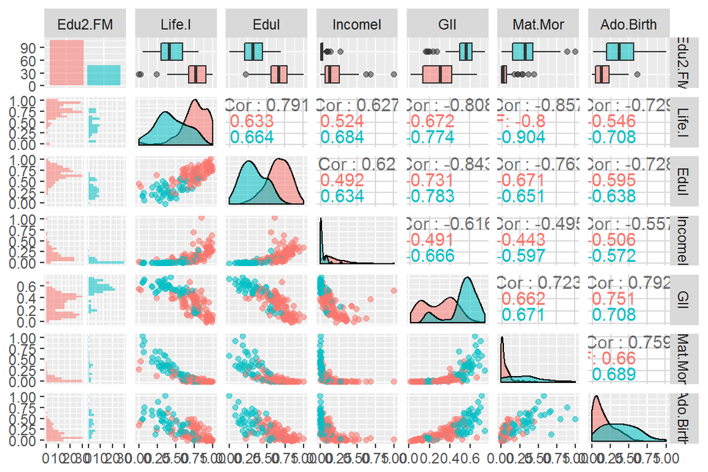

```r
library(ggplot2)
corPlot <- ggpairs(human, mapping = aes(col=Edu2.FM, alpha=0.3), lower = list(combo = wrap("facethist", bins = 20)))
corPlot
```

Since the correlation matrix values are high for almost all variables, before to choose which of them to include in the linear regression, we also analyse the correlation matrix plot excluding the factor variable **Edu2.FM**

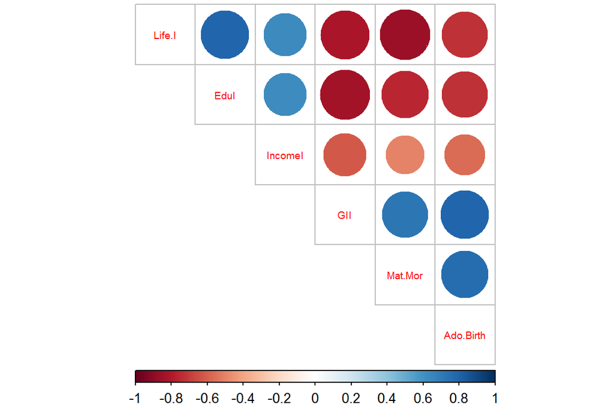

```r
library(GGally)
keep <- c("Life.I",  "EduI", "IncomeI", "GII", "Mat.Mor", "Ado.Birth")
human_ <- select(human, one_of(keep))
cor_matrix<-cor(human_)%>% round(digits =2)

corrplot(cor_matrix, method="circle", type = "upper", cl.pos = "b", tl.pos = "d", tl.cex = 0.6)
```

We observe that the greatest influence on life expectancy **Life.I** have the variables **EduI**, and **GII** and **Mat.Mor** both with negative sign. Therefore we include in the multiple linear regression only one of them. we choose **mat.Mor** because it has direct infuence on the life expectancy. And we also involve **IncomeI** variable because it should be important for achieving good living standard.

## 6.3.Multiple linear Regression: results and interpretation

### 6.3.1. Predicting life expentancy as output variable.

First we model life expectancy **Life.I** as an output of multiple regression model as folllow:

```r
my_model <- lm(Life.I ~ EduI + IncomeI + Mat.Mor, data = human)
summary(my_model)
```

```
##
## Call:
## lm(formula = Life.I ~ EduI + IncomeI + Mat.Mor, data = human)
##
## Residuals:
##      Min       1Q   Median       3Q      Max
## -0.48905 -0.05338  0.01175  0.07154  0.20201
##
## Coefficients:
##             Estimate Std. Error t value Pr(>|t|)
## (Intercept)  0.58337    0.04287  13.608  < 2e-16 ***
## EduI         0.23238    0.06755   3.440 0.000751 ***
## IncomeI      0.31903    0.07328   4.354 2.46e-05 ***
## Mat.Mor     -0.74747    0.06981 -10.707  < 2e-16 ***
## ---
## Signif. codes:  0 '***' 0.001 '**' 0.01 '*' 0.05 '.' 0.1 ' ' 1
##
## Residual standard error: 0.1079 on 151 degrees of freedom
## Multiple R-squared:  0.8043, Adjusted R-squared:  0.8004
## F-statistic: 206.8 on 3 and 151 DF,  p-value: < 2.2e-16
```

Next we analyse the parameter estimates and their standard errors. The intersect is a free parameter in the model. Its prediction is made by model when all independent variables are set to 0. We observe that the standard errors of all regression coefficients are satisfactory small.

The last column of coefficients statistics show the p-value for the corresponding regression coefficient. All p values < 0.05 suggesting that all inviolved coefficients are very significant. Therefore we cannot reduce the number of dependent variables.

### Diagnostic plots: Residuals vs Fitted values, Normal QQ-plot and Residuals vs Leverage. Model assumptions and their validity

We create residual plots for the investigated multivariate model:

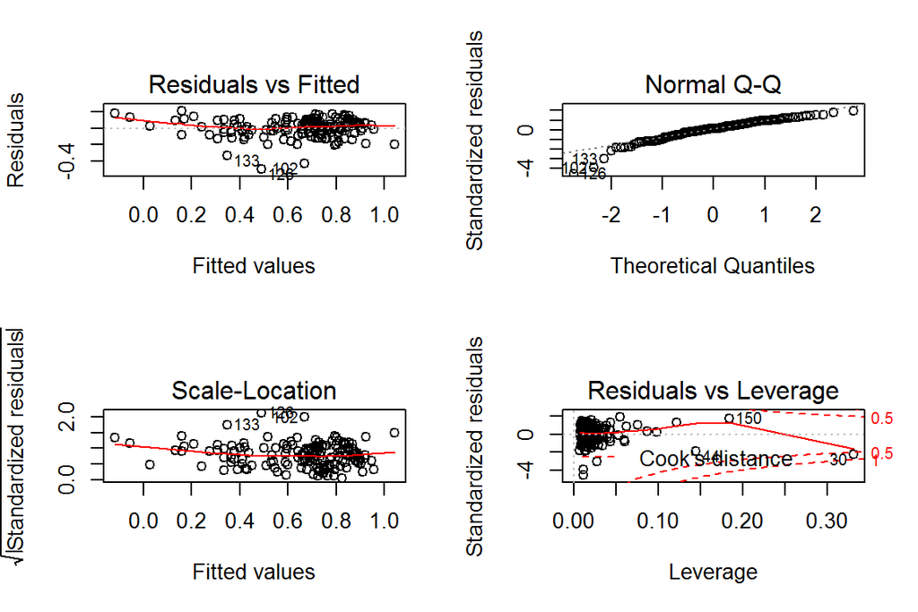

```r
par(mfrow=c(2,2))
plot(my_model)
```

The four residual plots show potential problematic cases with the row numbers of the data in the dataset.

Residuals versus Fitted values plot do not show any patterns. TPnly three outliers are shown. these are the data concderning countries with labels 102, 126 and 133.

Normality Q-Q plot is near to a straight line, which suggests normal distribution of errors. Again the countries with labels 102, 126 and 133 are shown as outliers.

Scale-location plot also do not show any pattern, thus suggesting absence of heteroskedansticity. Again the countries with labels 102, 126 and 133 are shown as outliers.

Residuals versus leverage plot helps us to find influential cases (i.e., subjects) if any. Here as outliers are shown observations for countries with labels 30, 44 and 150.

### 6.3.2. Predicting knowledge **EduI** as output variable.

In the second model we investigate **EduI** as an output variable. From the correlation matrix on Fig.2 we observe that **EduI** is highly correlated with **Life.I**, **GII** and less dependent on **Income**. We choose these three variables as dependent and apply multivariate linear regression.

```r
my_model1 <- lm(EduI ~ Life.I + GII + IncomeI, data = human)
summary(my_model1)
```

```
##
## Call:
## lm(formula = EduI ~ Life.I + GII + IncomeI, data = human)
##
## Residuals:
##      Min       1Q   Median       3Q      Max
## -0.26573 -0.07442  0.00837  0.08341  0.35278
##
## Coefficients:
##             Estimate Std. Error t value Pr(>|t|)
## (Intercept)  0.60404    0.06779   8.911 1.52e-15 ***
## Life.I       0.25323    0.06542   3.871 0.000161 ***
## GII         -0.63879    0.08165  -7.824 8.26e-13 ***
## IncomeI      0.15142    0.07812   1.938 0.054433 .
## ---
## Signif. codes:  0 '***' 0.001 '**' 0.01 '*' 0.05 '.' 0.1 ' ' 1
##
## Residual standard error: 0.111 on 151 degrees of freedom
## Multiple R-squared:  0.7514, Adjusted R-squared:  0.7465
## F-statistic: 152.1 on 3 and 151 DF,  p-value: < 2.2e-16
```

More interesting are results concerning parameter estimates. All four coefficientshave small standard errors.

The p-value in last column is low for the first three coefficients , p<0.05, suggesting that they are signifficant for the model. Surprisingly, the last parameter, **Income**, has boundary p=0.05 value, suggestin that this parameter could be excluded from the regression model.

Therefore we exclude **Income** from multiple regression and analyse the results.

```r
my_model2 <- lm(EduI ~ Life.I + GII, data = human)
summary(my_model2)
```

```
##
## Call:
## lm(formula = EduI ~ Life.I + GII, data = human)
##
## Residuals:
##      Min       1Q   Median       3Q      Max
## -0.27341 -0.07365  0.00482  0.08246  0.34745
##
## Coefficients:
##             Estimate Std. Error t value Pr(>|t|)
## (Intercept)  0.61583    0.06813   9.040 6.81e-16 ***
## Life.I       0.28845    0.06342   4.548 1.10e-05 ***
## GII         -0.67664    0.08000  -8.458 2.09e-14 ***
## ---
## Signif. codes:  0 '***' 0.001 '**' 0.01 '*' 0.05 '.' 0.1 ' ' 1
##
## Residual standard error: 0.112 on 152 degrees of freedom
## Multiple R-squared:  0.7452, Adjusted R-squared:  0.7419
## F-statistic: 222.3 on 2 and 152 DF,  p-value: < 2.2e-16
```

The summary of results in this model show that this choice of parameters is good because all coefficients in the model are significant (p<0.05), stadrad errors of estimates are small, and all other statistics results are satisfactory. Therefore we continue the with the analyses about this smaller model.

### Diagnostic plots: Residuals vs Fitted values, Normal QQ-plot and Residuals vs Leverage. Model assumptions and their validity

We create residual plots for the investigated multivariate model:

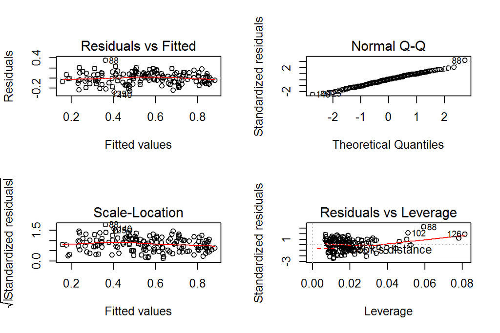

```r
par(mfrow=c(2,2))
plot(my_model2)
```

First three residual plots do not show any pattern suggesting that the chosen model is a good approximation. In all cases the same possible outliers are observed. These are the observations concerning countries with row numbers 88, 125 and 140.

## Analyses and conclusions

We have investigated two multivariate models for **human** data, concerning different measures about assessing development of a country. The models are created under the assumption that people and their capabilities (measures as possibility to obtain good knowledge and education and long and healthy life) are added to the economic growth.

In first model we have investigated the dependence of long and healthy life as an output variable, depending on education, income and mother mortality. The model analysis show that the choice of dependent variables is correct and the model is a good approximation to the observed data.

In the second model we investigate the possibility to obtain good education as output model variable, depending on life expecancy, gender inequaity index and income. Surpasingly in this case the model show that income is not so significant variable and the output results do not bedome worst if we exclude it from the depending variables. Thus we can conclude that surprisingly obtaining good knowledge is not so hevily dependent on gross national income per capita. There could be several explanations about this fact. For example in some countries like Finland the high education is still free of taxes, which gives almost equal opportunities to all young people.  
We should take into account the fact that the results shown here are obtained from variables, all of which showing quite high pairwise correlation. Therefore it is difficult to compare results and to select some variables as not significant.

## Link to to the GitHub page, related to my work on this assignment:

https://github.com/noykova/IODSFinalAssignment